# Bad weather damages on health and economy in the USA

Alessandro Puiatti

9/22/2017

This documet summarizes the data analysis performed over the NOAA Storm Database in order to understand which types of events are most harmful with respect to the population health and whcih have the greatest economic consequences. A detailed descritption of the event types and how the harmful and economic damage are computed can be found at the National Weather Service [Storm Data Documentation](https://d396qusza40orc.cloudfront.net/repdata%2Fpeer2_doc%2Fpd01016005curr.pdf)

## Data Processing

The amount of data reach almost 0.5GB, so it would be better not to load in memory the entire table but only the interested ones. For undertsanding which ones they are we first read 10 lines (the header an some data), just to have an idea of the data types and to recognize which are the cols that we have to load. In order to perform this operation we need to load two libraries: *data.table* and *R.utils*. For further computation other libraries are needed that are: *plyr* and *dplyr*.

```r
library(data.table)
library(R.utils,warn.conflicts = FALSE, quietly = TRUE, verbose = FALSE)
library(plyr) # for useful tools
library(dplyr, warn.conflicts = FALSE, quietly = TRUE, verbose = FALSE)
```

Therefore the first opeartions are: unzip the data file (already downloaded), read the first 10 lines on a variable (*firstLines*), and then look at them.

```r
bunzip2("repdata-data-StormData.csv.bz2", remove = F)
firstLines <- read.csv("repdata-data-StormData.csv", nrows = 10)
firstLines
```

```
##    STATE__           BGN_DATE BGN_TIME TIME_ZONE COUNTY COUNTYNAME STATE
## 1        1  4/18/1950 0:00:00      130       CST     97     MOBILE    AL
## 2        1  4/18/1950 0:00:00      145       CST      3    BALDWIN    AL
## 3        1  2/20/1951 0:00:00     1600       CST     57    FAYETTE    AL
## 4        1   6/8/1951 0:00:00      900       CST     89    MADISON    AL
## 5        1 11/15/1951 0:00:00     1500       CST     43    CULLMAN    AL
## 6        1 11/15/1951 0:00:00     2000       CST     77 LAUDERDALE    AL
## 7        1 11/16/1951 0:00:00      100       CST      9     BLOUNT    AL
## 8        1  1/22/1952 0:00:00      900       CST    123 TALLAPOOSA    AL
## 9        1  2/13/1952 0:00:00     2000       CST    125 TUSCALOOSA    AL
## 10       1  2/13/1952 0:00:00     2000       CST     57    FAYETTE    AL
##     EVTYPE BGN_RANGE BGN_AZI BGN_LOCATI END_DATE END_TIME COUNTY_END
## 1  TORNADO         0      NA         NA       NA       NA          0
## 2  TORNADO         0      NA         NA       NA       NA          0
## 3  TORNADO         0      NA         NA       NA       NA          0
```

[output cut: 40 more lines]

As can be seen from *firstLines* the cols that are of our interest, checking also their meanings in the [Storm Data Documentation](https://d396qusza40orc.cloudfront.net/repdata%2Fpeer2_doc%2Fpd01016005curr.pdf), are:

- EVTYPE
- FATALITIES
- INJURIES
- PROPDMG
- PROPDMGEXP
- CROPDMG
- CROPDMGEXP

So the next step si to extract from the database only these 7 cols

```r
cols <- c("EVTYPE", "FATALITIES", "INJURIES", "PROPDMG", "PROPDMGEXP",
          "CROPDMG", "CROPDMGEXP")
data <- fread("repdata-data-StormData.csv", select = cols, showProgress = F)
```

Now, just to have an idea of the memory allocated for *data*

```r
sprintf("Size of only seven columns in memory: %s MB", floor(utils::object.size(data)/1000000))
```

```
## [1] "Size of only seven columns in memory: 50 MB"
```

that is almost one-tenth of the total memory needed for the entire dataset. Now, we check for NAs values

```r
mean(is.na(data))
```

```
## [1] 0
```

Given that there are no NAs we don’t need to bother anymore about it in the next steps

The last operations needed for computing the summaries required are then:

1. reorganize the data grouped by *EVTYPE* for answering the question related to the population health (*dataHealth*), after havin selcted only the related cols from *data*
2. reorganize the data grouped by *EVTYPE*, for answering the question related to the most damageful event (*dataDmg*), after havin selcted only the related cols from *data*

#### Population health

Select the related cols and remove all rows with null values

```r
cols <- c("EVTYPE", "FATALITIES", "INJURIES")
dataHealth <- select(data, cols) %>%
        filter(FATALITIES != 0 & INJURIES != 0)
```

Group the data by *EVTYPE*, summarize, compute the percentages for *FATALITIES* and *INJURIES* and finally reordered the data in descending order

```r
sumHealth <- as.data.frame(group_by(dataHealth, EVTYPE) %>%
        summarize(sumFatal = sum(FATALITIES), sumInjury = sum(INJURIES )) %>%
        mutate(EVTYPE, sumFatal, percFatal = round(100*sumFatal/sum(sumFatal),2),
               sumInjury, percInj = round(100*sumInjury/sum(sumInjury),2)))

sumFatalities <- data.frame(sumHealth$EVTYPE, sumHealth$sumFatal, sumHealth$percFatal)
names(sumFatalities) <- c("EVTYPE", "Fatal", "percFatal")
sumFatalities <- setorder(sumFatalities, -Fatal)

sumInj <- data.frame(sumHealth$EVTYPE,sumHealth$sumInjury,sumHealth$percInj)
names(sumInj) <- c("EVTYPE", "Injury", "percInj")
sumInj <- setorder(sumInj, -Injury)
```

#### Damges

Select the related cols and remove all rows with null values

```r
cols <- c("EVTYPE", "PROPDMG", "PROPDMGEXP", "CROPDMG", "CROPDMGEXP")
dataDmg <- select(data, cols) %>%
        filter(PROPDMG != 0 & CROPDMG != 0)
```

The two cols *PROPDMGEXP* and *CROPDMGEXP* have to be converted in integers with the values equivalent to the amount of expressed unit (look at [Storm Data Documentation](https://d396qusza40orc.cloudfront.net/repdata%2Fpeer2_doc%2Fpd01016005curr.pdf)):

- 10<sup>3</sup> for *K*
- 10<sup>6</sup> for *M*
- 10<sup>9</sup> for *B*

However, looking at the chars presented in the two mention cols, we have other values than *K*, *M*, and *B*:

```r
unique(dataDmg$PROPDMGEXP)
```

```
## [1] "B" "M" "m" "K" "5" "0" ""  "3"
```

```r
unique(dataDmg$CROPDMGEXP)
```

```
## [1] "M" "K" "m" "k" "B" "0" ""
```

We can assume that the number “5”, “3” and “0” are the power of 10, “m” is equal to “M” and “k” is equal to “K”. The “” element would be considered as NA

```r
dataDmg$PROPDMGEXP <- as.numeric(revalue(dataDmg$PROPDMGEXP, c("K"=10^3, "M"=10^6, "m"=10^6,
                                                    "B"=10^9, "5"=10^5, "0"=1, "3"=10^3)))
dataDmg$CROPDMGEXP <- as.numeric(revalue(dataDmg$CROPDMGEXP, c("K"=10^3, "k"=10^3, "M"=10^6, "m"=10^6,
                                                    "B"=10^9, "0"=1)))
```

Then we can create a new table with the *PROPDMG* and *CROPDMG* computed in dollars

```r
dataDmg <- transmute(dataDmg, EVTYPE, PROPDMG = PROPDMG*PROPDMGEXP, CROPDMG = CROPDMG*CROPDMGEXP)
```

Group the data by *EVTYPE*, summarize and compute also the percentages for *CROPDMG* and *PROPDMG*

```r
sumDmg <- group_by(dataDmg, EVTYPE) %>%
       summarize( sumCrop = sum(CROPDMG, na.rm = T), sumProp = sum(PROPDMG,na.rm = T)) %>%
        mutate(EVTYPE, sumProp, percProp = round(100*sumProp/sum(sumProp),2),
               sumCrop, percCrop = round(100*sumCrop/sum(sumCrop),2))

sumCrop <- data.frame(sumDmg$EVTYPE, sumDmg$sumCrop, sumDmg$percCrop)
names(sumCrop) <- c("EVTYPE", "Crop", "percCrop")
sumCrop <- setorder(sumCrop, -Crop)

sumProp <- data.frame(sumDmg$EVTYPE,sumDmg$sumProp,sumDmg$percProp)
names(sumProp) <- c("EVTYPE", "Prop", "percProp")
sumProp <- setorder(sumProp, -Prop)
```

Remove unnecessary data

```r
rm(list = c("data","dataDmg","dataHealth","firstLines","cols"))
```

## Results

Having done all the preparatory data processing what is left now is to look at the results following the two main questions.

#### Across the United States, which types of events are most harmful with respect to population health?

For answering this question we have to look in the *sumHealth* datase and find which event is more harmful considering separately the *FATALITIES* and the *INJURIES*. Looking at the *sumHealth* data it turns out, and it makes sense, that the *Tornado* is the most harmful for both cases. However, the same progression does not follow equally for the other events, as reported in the following table for the first 5 calamities more harmful that account for the 82.85%, in the case of *FATALITIES*, and the 89.63 for the *INJURIES*

```r
library(gridExtra)
```

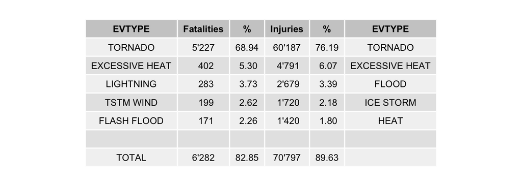

```r
temp <- format(data.frame(sumFatalities[1:5,1], sumFatalities[1:5,2:3], sumInj[1:5,2:3], sumInj[1:5,1]), big.mark = "'")

grid.table(rbind(temp,setNames(data.frame("","","","","",""), names(temp)),
                 setNames(data.frame("TOTAL", format(sum(sumFatalities[1:5,2]), big.mark = "'"),
                 sum(sumFatalities[1:5,3]),format(sum(sumInj[1:5,2]), big.mark = "'"),
                 sum(sumInj[1:5,3]),""),names(temp))), cols = c("EVTYPE", "Fatalities", "%", "Injuries",
                 "%", "EVTYPE"), rows = NULL,  ttheme_default(base_size = 9))
```

In the following figures, indeed, it is possible to see how they are distributed for the first 5 calamities more harmful.

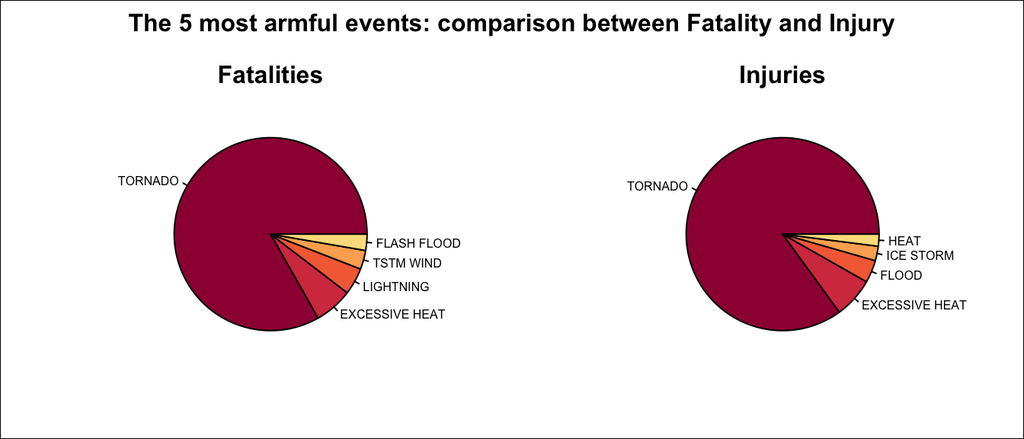

The 5 weather events that casues Fatalities and Ingiuries

```r
library(RColorBrewer)
colors = brewer.pal(10,"Spectral")

par(oma= c(0,0,3,0), mfrow=c(1,2),cex=0.5, cex.main=2)

pie(sumFatalities$Fatal[1:5],sumFatalities$EVTYPE[1:5], col=colors, main = "Fatalities")
pie(sumInj$Injury[1:5],sumInj$EVTYPE[1:5], col=colors, main = "Injuries")
title(main = "The 5 most armful events: comparison between Fatality and Injury", outer = T)
box("outer")
```

#### Across the United States, which types of events have the greatest economic consequences?

As can be seen in the following graphs, in thsi case only the costs for the Property damage has a very high peak for a specific event, whyle the cost distribution for the Crop damage is more smooth. Moreover, differently from the previous case, the event that have the greatest economic conseuqences Property and Crop is not the same.

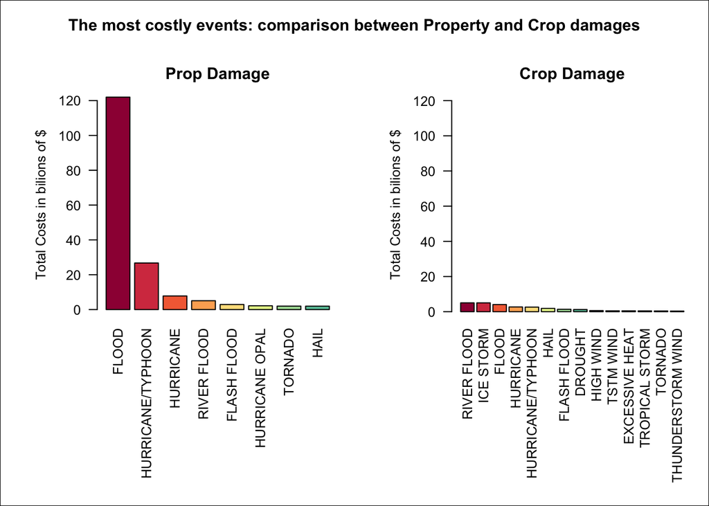

Comparison between the most costly events that generate Property and Crop damage. The values represented on the plot are the ones greater than the mean for each case.

```r
par(oma= c(0,0,3,0), mar=c(12,6,3,1), mfrow=c(1,2), cex = 0.8)

barplot((sumProp[which(sumProp$Prop > mean(sumProp$Prop)),2])/10^9,
        names.arg = sumProp[which(sumProp$Prop > mean(sumProp$Prop)),1],
        las = 2, col = colors, ylab = "Total Costs in bilions of $", main = "Prop Damage")

barplot((sumCrop[which(sumCrop$Crop >  mean(sumCrop$Crop)),2])/10^9,
        names.arg = sumCrop[which(sumCrop$Crop > mean(sumCrop$Crop)),1],
        las = 2, ylim = c(min(sumProp$Prop)/10^9, max(sumProp$Prop)/10^9),
        ylab = "Total Costs in bilions of $", main = "Crop Damage", col = colors)

title(main = "The most costly events: comparison between Property and Crop damages", outer = T)
box("outer")
```